# Lecture 04

### 1.2.3 `aes()` determines attributes of the mapping list and how data is displayed

The next step is to choose the data we are plotting **(aesthetics)** and how it influences the visualization. At this point the data can be **scaled** directly and the axes appear. We have not yet specified *how* we want the data plotted, only *which* data should be plotted. In practice, people usually omit ‘mapping =’, but it is a good reminder that mapping is, in fact, what we are doing.

When we start customizing our plot, our code starts to get a bit harder to read on one line. We can create each specification on a new line by ending each line with a `+`.

For our plot, we’ll specify the x and y axis using data from the `area` (total area of the worm imaged in pixels<sup>2</sup>) and `area.infected` variables. Note that both of these variables are also numerical in nature, representing a wide range of values. These kinds of values could be considered **continuous** variables.

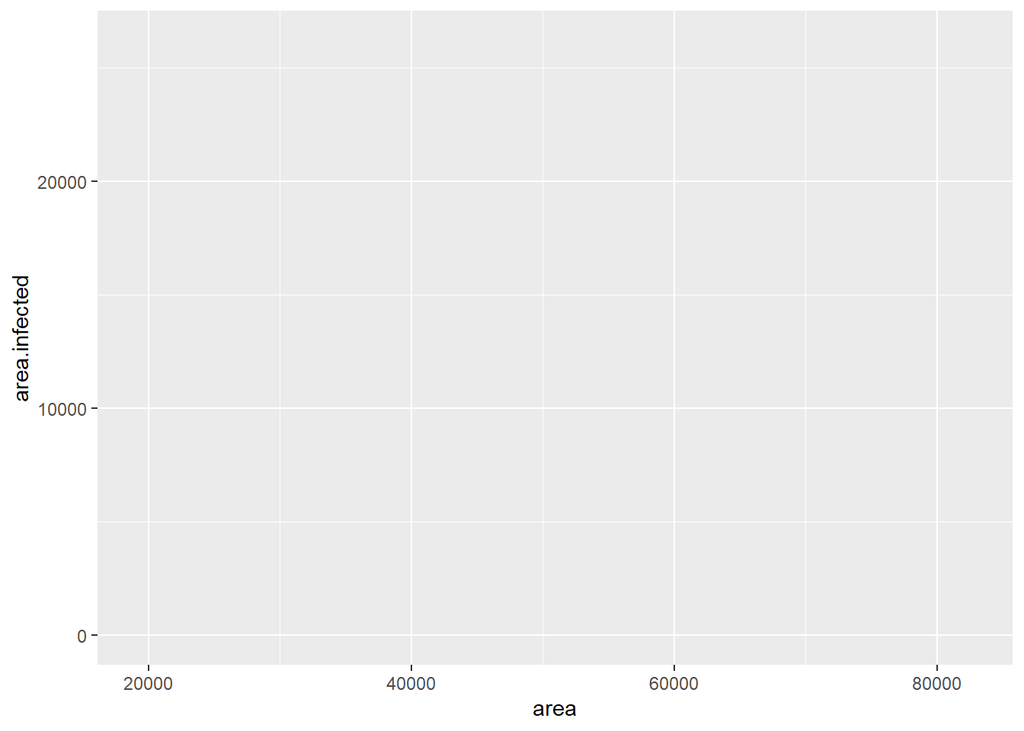

```r
# Add the aes() parameter to our plot
ggplot(data = infection_sig.df, mapping = aes(x = area, y = area.infected ))
```

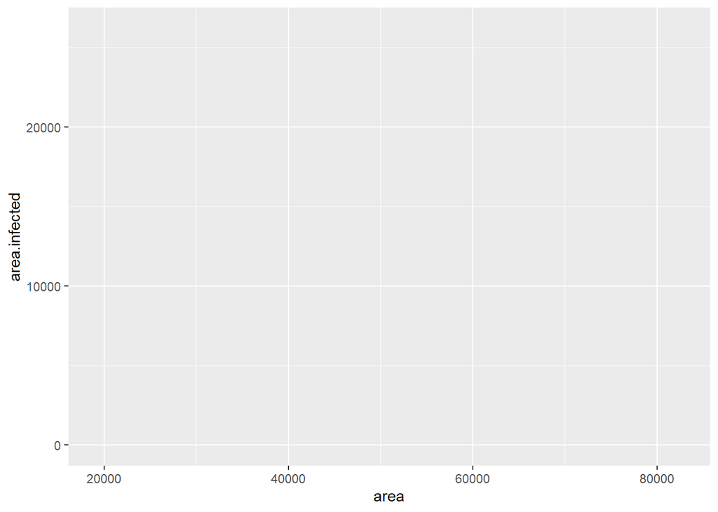

```r
# We can make it equivalent by adding aes() like a layer
# 1. Data
ggplot(infection_sig.df) +

    # 2. Aesthetics to map the x and y-axis to variables in our data
    aes(x = area, y = area.infected)
```

### 1.2.4 Visualize our data as points on the graph with `geom_point()`

We now have to choose the **geometric object** (`geom`) with which to plot our data, in this case a point. A `geom` could be a line, a bar, a boxplot - you can type `geom_` and then `Tab` to see all of the available options. *Autocomplete* can also be helpful for remembering syntax.

Some helpful geom commands:

| Command | Geom description | Used for |
| --- | --- | --- |
| `geom_point()` | Single points of data plotted on an x and y axis | scatterplots, dotplots, bubble charts |
| `geom_bar()` | Barchart summarizing data based with heights proportional to size of its group | barplots and stacked barplots |
| `geom_col()` | Barchart summarizing data where with heights representing values in the data | barplots of data values? |
| `geom_boxplot()` | Produce a rough visualization of data distribution | boxplots |
| `geom_line()` | Track values of multiple groups along an x-axis such as time | line graphs |
| `geom_jitter()` | When datapoint overlap too much, you can spread them out using jitter | Helpful for boxplots |
| `geom_violin()` | Combines a kernel distribution estimate in a boxplot-style format | Known as the violin plot |

For our particular plot, we are making a scatterplot so we’ll want to go with the `geom_point()` function. Let’s add that layer to the plot with the `+` syntax.

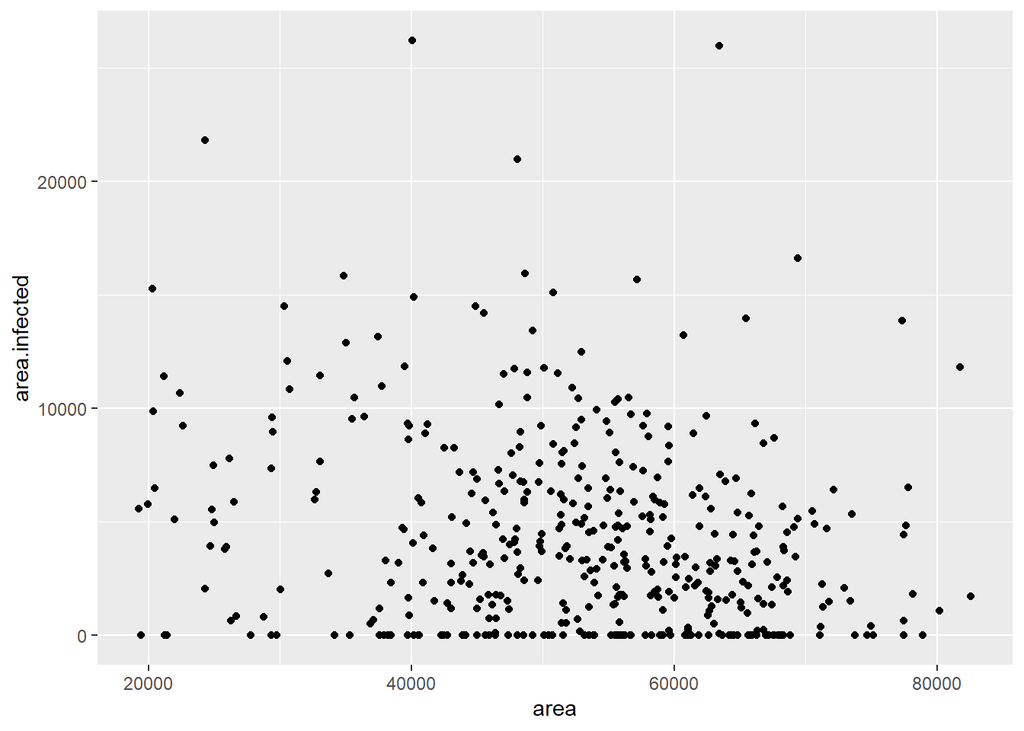

```r
# Add our data points to the ggplot object
# 1. Data
ggplot(infection_sig.df) +
    # 2. Aesthetics to map the x and y-axis to variables in our data
    aes(x = area, y = area.infected) +
    # 3. Scaling
    # 4. Geoms
    geom_point()
```

### 1.2.5 Specify colouring of groups through `aes()` based on Factors

The data looks like there perhaps may be two groupings with a larger central distribution. My guess would be that there may be different distributions of our points based on worm strain. We can easily test this by colouring our points by the `strain` variable.

First let’s look at the structure of `infection_sig.df` in either the Global Environment or using `str()`. To do this in R, we want to base our colouring on levels from a `factor`. Afterwards a legend will be automatically created for you.

To accomplish this, we first need to make sure that `strain` is a column of type `Factor`. We’ll convert some additional variables to `Factor` at the same time.

```r
print("Our original infection file")
```

```
## [1] "Our original infection file"
```

```r
str(infection_sig.df, give.attr = FALSE)
```

```
## spc_tbl_ [456 x 14] (S3: spec_tbl_df/tbl_df/tbl/data.frame)
##  $ exp.name        : chr [1:456] "N2-LUAm1-1.8" "N2-LUAm1-1.8" "N2-LUAm1-1.8" "N2-LUAm1-1.8" ...
##  $ strain          : chr [1:456] "N2" "N2" "N2" "N2" ...
##  $ spore.strain    : chr [1:456] "LUAm1" "LUAm1" "LUAm1" "LUAm1" ...
##  $ spore.species   : chr [1:456] "N.ferruginous" "N.ferruginous" "N.ferruginous" "N.ferruginous" ...
##  $ dose            : chr [1:456] "pulse-72H" "pulse-72H" "pulse-72H" "pulse-72H" ...
##  $ spores          : num [1:456] 1.8 1.8 1.8 1.8 1.8 1.8 1.8 1.8 1.8 1.8 ...
##  $ fixing.date     : chr [1:456] "rep1" "rep1" "rep1" "rep1" ...
##  $ slide           : num [1:456] 1 1 1 1 1 1 1 1 1 1 ...
##  $ file            : chr [1:456] "N2.LUAm1.rep1" "N2.LUAm1.rep1" "N2.LUAm1.rep1" "N2.LUAm1.rep1" ...
##  $ worm.number     : num [1:456] 1 2 3 4 5 6 7 8 9 10 ...
##  $ area            : num [1:456] 49838 50425 45533 46459 49215 ...
##  $ percent.infected: num [1:456] 18.53 0 31.16 3.88 0 ...
##  $ area.infected   : num [1:456] 9235 0 14188 1803 0 ...
##  $ timepoint       : chr [1:456] "72hpi" "72hpi" "72hpi" "72hpi" ...
```

```r
# Update our dataframe to convert some variables to factors
infection_sig.df <-
  infection_sig.df %>%
  # Use the mutate function to replace variables with factor versions of themselves
  mutate(strain = factor(strain),
         spore.strain = factor(spore.strain),
         spore.species = factor(spore.species),
         fixing.date = factor(fixing.date),
         dose = factor(dose))

# Take a look at the resulting changes
str(infection_sig.df)
```

```
## tibble [456 x 14] (S3: tbl_df/tbl/data.frame)
##  $ exp.name        : chr [1:456] "N2-LUAm1-1.8" "N2-LUAm1-1.8" "N2-LUAm1-1.8" "N2-LUAm1-1.8" ...
##  $ strain          : Factor w/ 4 levels "AWR144","AWR145",..: 4 4 4 4 4 4 4 4 4 4 ...
##  $ spore.strain    : Factor w/ 1 level "LUAm1": 1 1 1 1 1 1 1 1 1 1 ...
##  $ spore.species   : Factor w/ 1 level "N.ferruginous": 1 1 1 1 1 1 1 1 1 1 ...
##  $ dose            : Factor w/ 1 level "pulse-72H": 1 1 1 1 1 1 1 1 1 1 ...
##  $ spores          : num [1:456] 1.8 1.8 1.8 1.8 1.8 1.8 1.8 1.8 1.8 1.8 ...
##  $ fixing.date     : Factor w/ 3 levels "rep1","rep2",..: 1 1 1 1 1 1 1 1 1 1 ...
##  $ slide           : num [1:456] 1 1 1 1 1 1 1 1 1 1 ...
##  $ file            : chr [1:456] "N2.LUAm1.rep1" "N2.LUAm1.rep1" "N2.LUAm1.rep1" "N2.LUAm1.rep1" ...
##  $ worm.number     : num [1:456] 1 2 3 4 5 6 7 8 9 10 ...
##  $ area            : num [1:456] 49838 50425 45533 46459 49215 ...
##  $ percent.infected: num [1:456] 18.53 0 31.16 3.88 0 ...
##  $ area.infected   : num [1:456] 9235 0 14188 1803 0 ...
##  $ timepoint       : chr [1:456] "72hpi" "72hpi" "72hpi" "72hpi" ...
```

**How could we have saved ourselves a little trouble by avoiding the mutate command?**

Now that we’ve set up some factors within our dataframe, we can begin to use these to help manage some of the information in our visualizations. Note also here that we’ve converted variables of a nature that break our data into distinct groups. These kinds of variables are also known as **categorical** variables.

### 1.2.5.1 Set aesthetics parameters within the `aes()` layer

The `aes()` layers can be used to set various aspects about our visualization using either **continuous** or **categorical** variables. *Some* of the aesthetics that can be adjusted include:

- `colour`: Set the colour of your `geom_*()` components if applicable like points and lines.
- `fill`: Set the fill colour of certain 2-D `geom_*()` components like points and bars.
- `shape`: Set the shape of your `geom_*()` components like points. This is only suggested for categorical variables.
- `size`: Set the size of some `geom_*()` layers like points - compatible with continuous and categorical variables.

By now you may have noticed that we have been setting specific attributes in an order that matches our diagram of the grammar of graphics pyramid. Keeping this kind of format simplifies the process of tweaking your plots as you first create them.

For our current efforts, let’s map the parameter of `colour` to our categorical variable `strain` when we first specify ‘x’ and ‘y’. Before we do that, however, we’ll add a `filter()` step to our data so that we are only looking at two specific strains - N2 and JU1400.

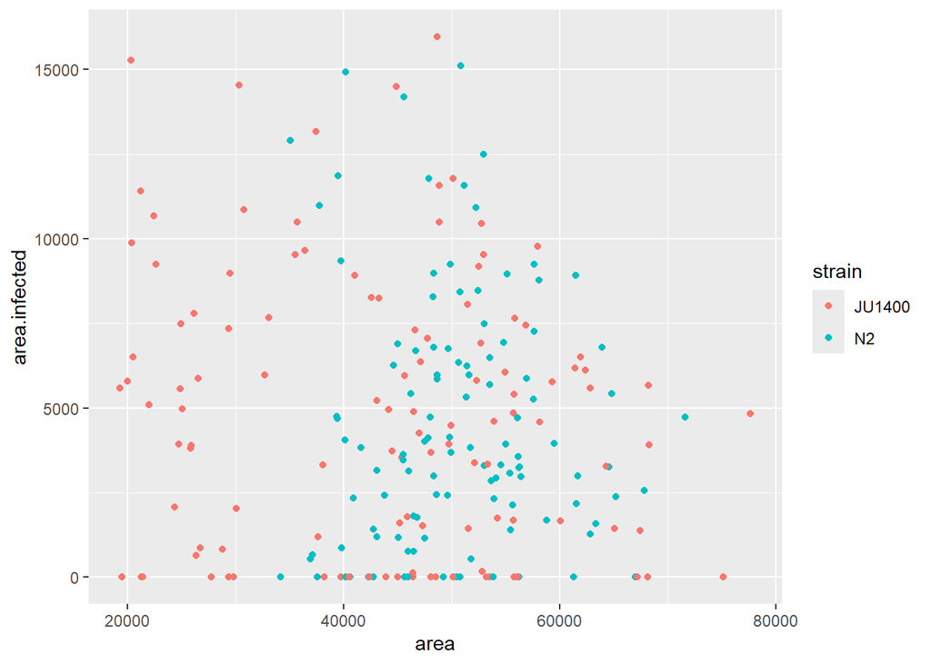

```r
# Add our data points to the ggplot object
infection_sig.df %>%
  # Filter the strains we'll investigate
  filter(strain %in% c("N2", "JU1400")) %>%

  # 1. Data
  ggplot(.) +
    # 2. Aesthetics
    aes(x = area, y = area.infected, colour = strain) +
    # 3. Scaling
    # 4. Geoms
    geom_point()
```

From our data, it looks like we have some overlapping data points but a whole set of JU1400 datapoints that is separate from the population of N2 data!

### 1.2.6 Most layers will, by default, inherit from `aes()` unless explicitly specified

When setting the mapping parameter with `aes()` there are generally three ways to do this in order of inheritance or precedence

1. `ggplot(data = ... , mapping = (aes(x = ..., y = ..., colour = ...)))`
2. `(aes(x = ..., y = ..., colour = ...))`
3. `geom_*(aes(x = ..., y = ..., colour = ...))`

This means that colour can be specified using `geom_point(aes())` since it is a description of the points being plotted. When building a plot, using this command will supersede the plot’s default mappings (if any were created and inherited). By placing version **(2)** into our code, at the beginning of our plot, we are essentially overriding the default mappings, which are nothing. I prefer to write the code this way for easier reading but method **(1)** is the more formal way of setting a default mapping to your plot.

It is less common that you might use option **(3)** but not impossible. Especially when layering multiple `geom_*()` objects, you may find that you want them coloured in one way, but shaped or sized based on a different factor. Setting the default mappings at the start reduces the effort of adding this information into each new layer of your ggplot object. That’s right, you can have *multiple geoms* in the same visualization.

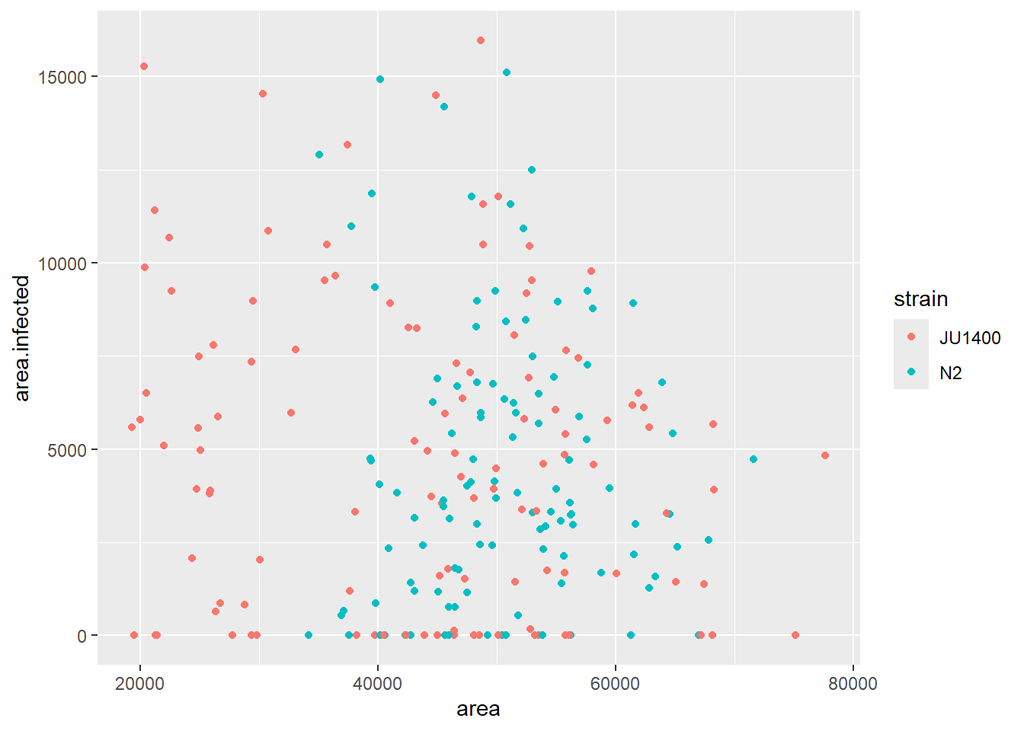

```r
#is equivalent in final output to but subsequent layers won't inherit this! compare the consequences

# Add our data points to the ggplot object
infection_sig.df %>%
  # Filter the strains we'll investigate
  filter(strain %in% c("N2", "JU1400")) %>%

  # 1. Data
  ggplot(.) +
    # 2. Aesthetics
    aes(x = area, y = area.infected) +
    # 3. Scaling
    # 4. Geoms
    ### 1.2.6 set colour by the geom layer
    geom_point(aes(colour = strain))
```

### 1.2.7 Altering the scale layer of our axes with `scale_y_*()`

Some of our data points seem to be compressed along the x-axis. We can see our y-axis ranges from 0 to ~15000. That’s a large range so what might those lower values represent?

Sometimes when we encounter this kind of issue, we can **scale** the y-axis to get a better look. There are a number of ways to specify how *either* of the axes of our graph can be scaled. This is usually accomplished through the commands

`scale_y_*()` and `scale_x_*()` where **`*`** denotes a number of options in R including:

- `discrete`
- `continuous`
- `log10`

Within these commands we can further specify parameters like the the axis `name`, `limits` (start and end), `breaks` (tick mark locations), `labels` for each break, and `transform` to alter how the axis is displayed without altering the data. In this case, let’s keep it simple and log-transform our y-axis with `scale_y_log10`. This will result in stretching out our smaller values a little bit more and compressing our larger values together.

```
## Warning in scale_y_log10(): log-10 transformation introduced
## infinite values.
```

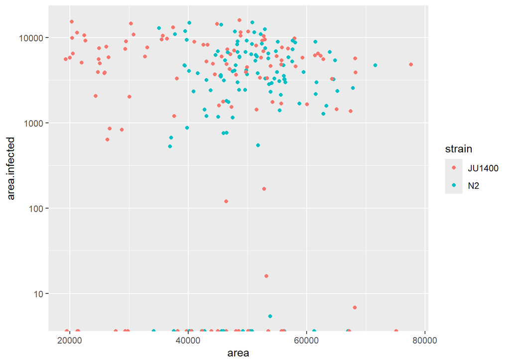

```r
# Convert the y-axis to a log10 scale

# Add our data points to the ggplot object
infection_sig.df %>%
  # Filter the strains we'll investigate
  filter(strain %in% c("N2", "JU1400")) %>%

  # 1. Data
  ggplot(.) +
    # 2. Aesthetics
    ### 1.2.7 set colour by the aes layer
    aes(x = area, y = area.infected, colour = strain) +
    # 3. Scaling
    scale_y_log10() +
    # 4. Geoms
    geom_point()
```

*While these kind of values are still plotted*, the warning suggests that we have done something improper.

### 1.2.8 Alter the scale of axes directly in `aes()`

Keep in mind that *scaling does not change the data*, but rather the representation of the data. The y-axis has been scaled. This is different than taking the log<sub>10</sub> of the y-axis data.

Can we transform our data directly? Yes, by manipulating the data in our specification of the y-axis data itself in our `aes()` call but we also need to make a small tweak because, of course, we will run into the same problem because

$$log_{10}(0) = undefined$$
but…

$$log_{10}(0 + 1) = 0$$

So we can update any 0 values in our data during the time of the log<sub>10</sub> transformation. Afterwards take a close look at the resulting y-axis as well!

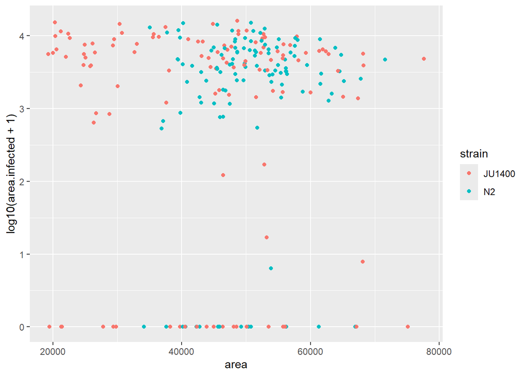

```r
# Update the y-axis aesthetic to scale the data directly.

# Add our data points to the ggplot object
infection_sig.df %>%
  # Filter the strains we'll investigate
  filter(strain %in% c("N2", "JU1400")) %>%

  # 1. Data
  ggplot(.) +
    # 2. Aesthetics
    aes(x = area, y = log10(area.infected + 1), colour = strain) +
    # 3. Scaling
    # 4. Geoms
    geom_point()
```

The placement of the points looks similar, but the first graph is scaling the axis while the second graph has transformed the data values on a log<sub>10</sub> scale. Can you see the difference? Take a good look at the name of our y-axis as well!

**Don’t be careless with your transformations!** While our solution above seemed quite simple, you should proceed with caution when encountering issues like these. Depending on the scale of your values, you may wish pause before deciding to add 1 to your values. You could choose to add smaller values or simply filter your 0 values out. Your choices will depend on your needs.

### 1.2.8.1 You can assign complex data transformations in `aes()`

As you can see from above, we performed multiple calculations in our transformation of the `area.infected` variable. You might have noticed there is also a `percent.infected` variable in our data as well. However, we can also calculate these values directly in the `aes()` assignment of the y-axis.

Let’s see how to access those values.

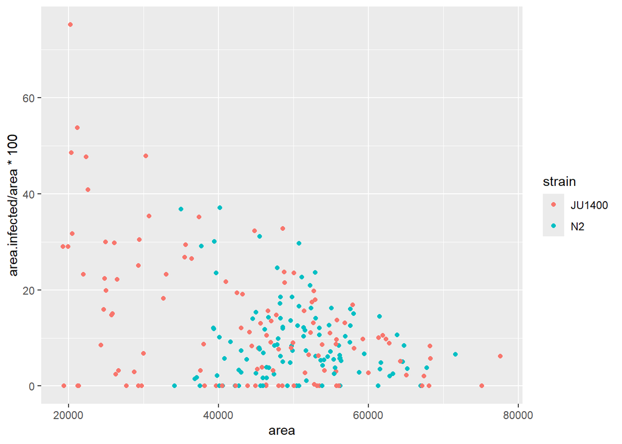

```r
# Calculate percent area infected and compare to just using the supplied variable

# Add our data points to the ggplot object
infection_sig.df %>%
  # Filter the strains we'll investigate
  filter(strain %in% c("N2", "JU1400")) %>%

  # 1. Data
  ggplot(.) +
    # 2. Aesthetics
    aes(x = area, y = area.infected/area*100, colour = strain) +
    # 3. Scaling
    # 4. Geoms
    geom_point()
```

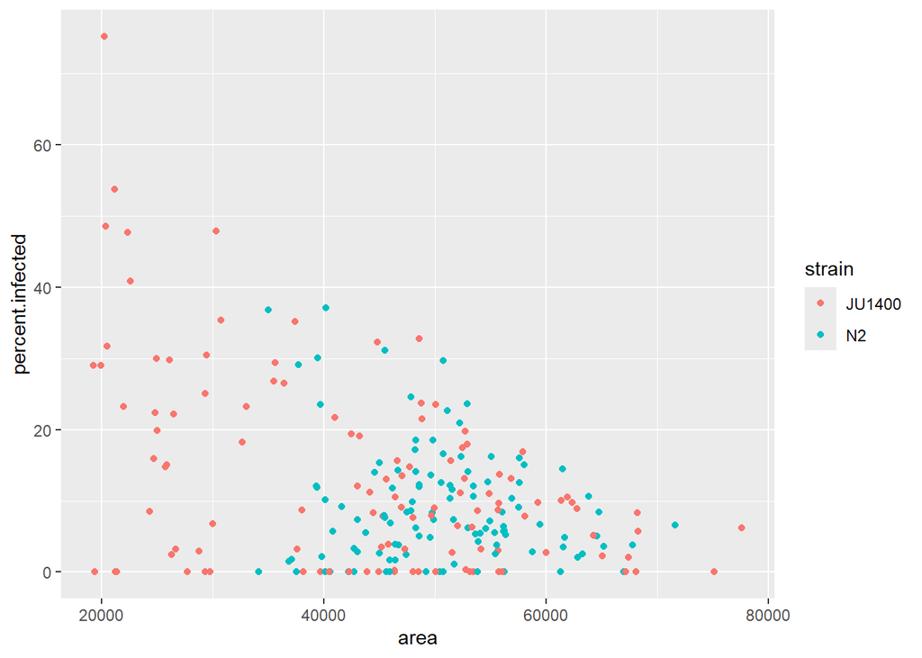

```r
# equivalent to using a pre-calulcated variable
# Use the provided variables of percent.infected
infection_sig.df %>%
  # Filter the strains we'll investigate
  filter(strain %in% c("N2", "JU1400")) %>%

  # 1. Data
  ggplot(.) +
    # 2. Aesthetics
    aes(x = area, y = percent.infected, colour = strain) +
    # 3. Scaling
    # 4. Geoms
    geom_point()
```

### 1.2.9 Take advantage of `facet_*()` to display multiple conditions in separate panels

**Faceting** allows us to split our data into groups to display in a more separated fashion. This can be helpful when working with multiple overlapping sets of data. By separating data into distinct panels, it can be easier to identify patterns or abnormalities. Note that we have removed the colour specification in our groups as splitting the data into separate graphs accomplishes the same distinction.

There are two facet options to work with:

1. `facet_grid()` - this will allow you to facet data by distinct groupings (**i.e. factor levels**) as columns and/or rows that form grids. This will create plots even where data does not exist for a specified group.
2. `facet_wrap()` - this will facet your data based on a specified grouping (also potentially factor levels or distinct values) but will not produce facets (panels) where data does not exist.

**Keep things simple:** It is good data visualization practice to only have one attribute (colour, shading, faceting, symbols) per grouping. Basically, by choosing carefully, you can represent each attribute of your data across a single visual dimension rather than across multiple ones. This saves on having overly-complicated visualizations and legends.

Let’s facet our data by worm strain using `facet_grid()` and make use the following parameters throughout the following sections:

- `rows` and `cols` - the set of variables used to group your data across rows and columns. These can also accepts a `rowVars ~ colVars` formula syntax where `rowVars` and `colVars` are grouping variables from your data.
- `scales` - used to determine whether x and y axis scales are shared or distinct along individual panels.
- `labeller` - takes in a data frame of labels and returns a list or data frame of character vectors. This is helpful for renaming each of your panel titles (aka facet labels).

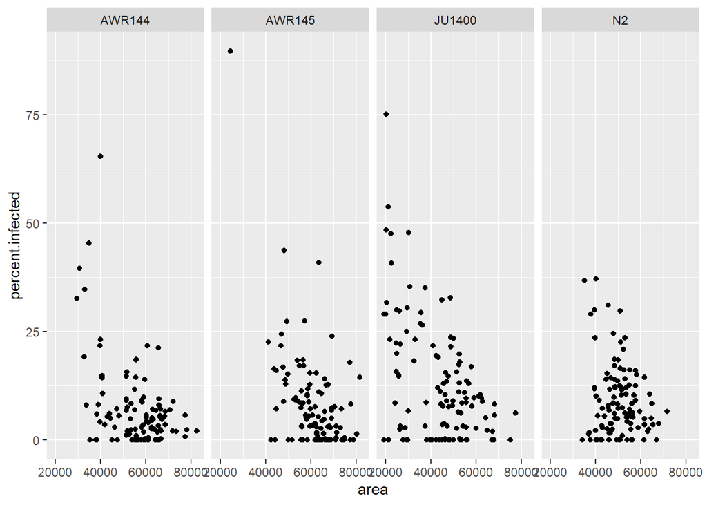

```r
# Update our aesthetics and add a facet

# Add our data points to the ggplot object
infection_sig.df %>%

  # 1. Data
  ggplot(.) +
    # 2. Aesthetics
    aes(x = area, y = percent.infected) +
    # 3. Scaling
    # 4. Geoms
    geom_point() +
    # 6. Facets
    facet_grid(. ~ strain) # use facet_grid to split panels by worm strain
```

### 1.2.10 Updating the image size in R Markdown through the code cell definition `{r}`

You may have noticed that when your legends or axes text are quite large, you lose some real estate on your actual graph. This is due to how we output the graphs both when saving and in displaying. In R markdown, the standard output dimension is a 7-inch wide and 5-inch high graph.

When displaying your graphs in R markdown you can update `options` through the definition of the code cell `{r}` using the `fig.width` and `fig.height` options to widen or lengthen graphs as you create them with big legends or multiple facets. You’ll need to set this manually for each figure we produce in the notebook. We’ll talk about the process of saving them soon as well. First, let’s fix our previous graph.

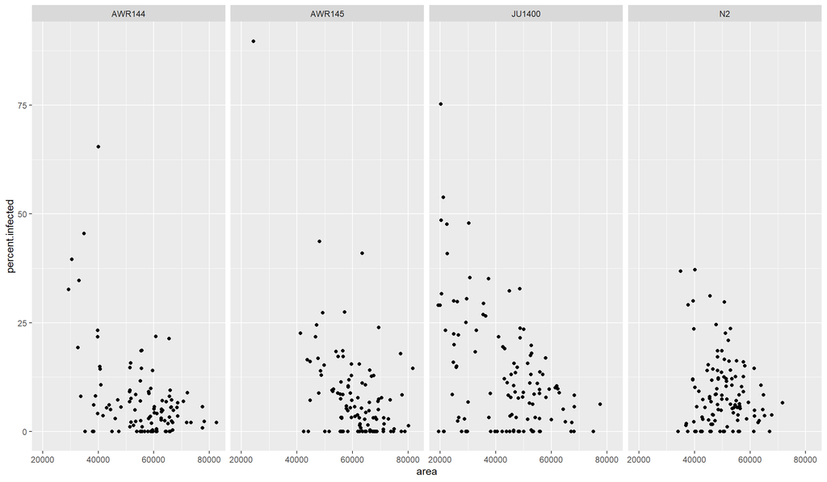

```r
# Update our aesthetics and add a facet

# Add our data points to the ggplot object
infection_sig.df %>%

  # 1. Data
  ggplot(.) +
    # 2. Aesthetics
    aes(x = area, y = percent.infected) +
    # 3. Scaling
    # 4. Geoms
    geom_point() +
    # 6. Facets
    facet_grid(. ~ strain) # use facet_grid to split panels by worm strain
```

### 1.2.11 Plots can be coloured using continuous variables

We could now add information from another variable as a colour in this plot. Note that if a variable is continuous instead of discrete, the colour will be a gradient. Let’s switch back to using `area.infected` for our y-axis and proceed to colour our points by `percent.infected`. We’ll go back to looking at just the N2 and JU1400 strains from our dataset.

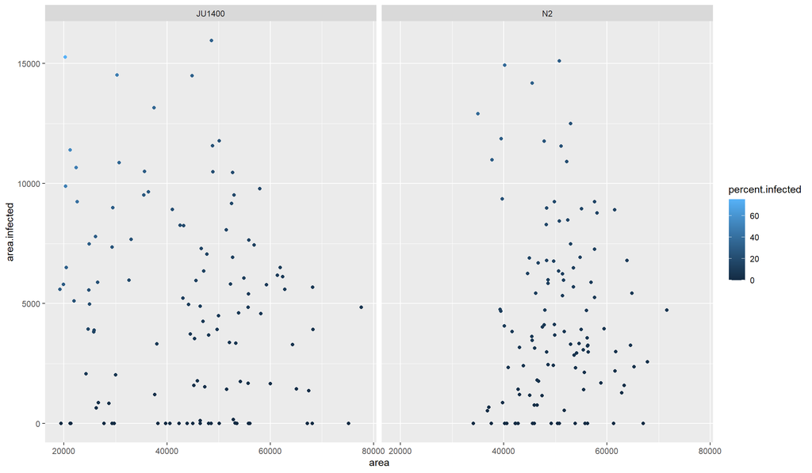

```r
# Update our aesthetics to colour by area.infected

# Add our data points to the ggplot object
infection_sig.df %>%
  # Filter the strains we'll investigate
  filter(strain %in% c("N2", "JU1400")) %>%

  # 1. Data
  ggplot(.) +
    # 2. Aesthetics
    aes(x = area, y = area.infected, colour = percent.infected) +
    # 3. Scaling
    # 4. Geoms
    geom_point() +
    # 6. Facets
    facet_grid(. ~ strain) # use facet_grid to split panels by worm strain
```

Notice how our points are coloured from dark blue (nearly black) to a lighter blue? This is the default colour gradient but there are ways to specify this as well! We’ll explore colours a little more in section **3.2.0**.

### 1.2.12 Discriminate your variables by shape in the `aes()` parameters

From our data, there are multiple replicates represented as “repX” within the `fixing.date` variable. We can explore the consistency of our biological replicates as another dimension in our data by using it to adjust the shape of our points. Let’s associate shape with `fixing.date` and see if that clarifies anything for us in the visualization. We’ll update the size of our points as well to make things clearer.

Recall that shape can only be used for discrete values.

A quick reference key for shapes can be found in the ‘Cookbook for R’ (http://www.cookbook-r.com/Graphs/Shapes_and_line_types/).

```r
# Revisit the structure of our infection signal dataset
str(infection_sig.df)
```

```
## tibble [456 x 14] (S3: tbl_df/tbl/data.frame)
##  $ exp.name        : chr [1:456] "N2-LUAm1-1.8" "N2-LUAm1-1.8" "N2-LUAm1-1.8" "N2-LUAm1-1.8" ...
##  $ strain          : Factor w/ 4 levels "AWR144","AWR145",..: 4 4 4 4 4 4 4 4 4 4 ...
##  $ spore.strain    : Factor w/ 1 level "LUAm1": 1 1 1 1 1 1 1 1 1 1 ...
##  $ spore.species   : Factor w/ 1 level "N.ferruginous": 1 1 1 1 1 1 1 1 1 1 ...
##  $ dose            : Factor w/ 1 level "pulse-72H": 1 1 1 1 1 1 1 1 1 1 ...
##  $ spores          : num [1:456] 1.8 1.8 1.8 1.8 1.8 1.8 1.8 1.8 1.8 1.8 ...
##  $ fixing.date     : Factor w/ 3 levels "rep1","rep2",..: 1 1 1 1 1 1 1 1 1 1 ...
##  $ slide           : num [1:456] 1 1 1 1 1 1 1 1 1 1 ...
##  $ file            : chr [1:456] "N2.LUAm1.rep1" "N2.LUAm1.rep1" "N2.LUAm1.rep1" "N2.LUAm1.rep1" ...
##  $ worm.number     : num [1:456] 1 2 3 4 5 6 7 8 9 10 ...
##  $ area            : num [1:456] 49838 50425 45533 46459 49215 ...
##  $ percent.infected: num [1:456] 18.53 0 31.16 3.88 0 ...
##  $ area.infected   : num [1:456] 9235 0 14188 1803 0 ...
##  $ timepoint       : chr [1:456] "72hpi" "72hpi" "72hpi" "72hpi" ...
```

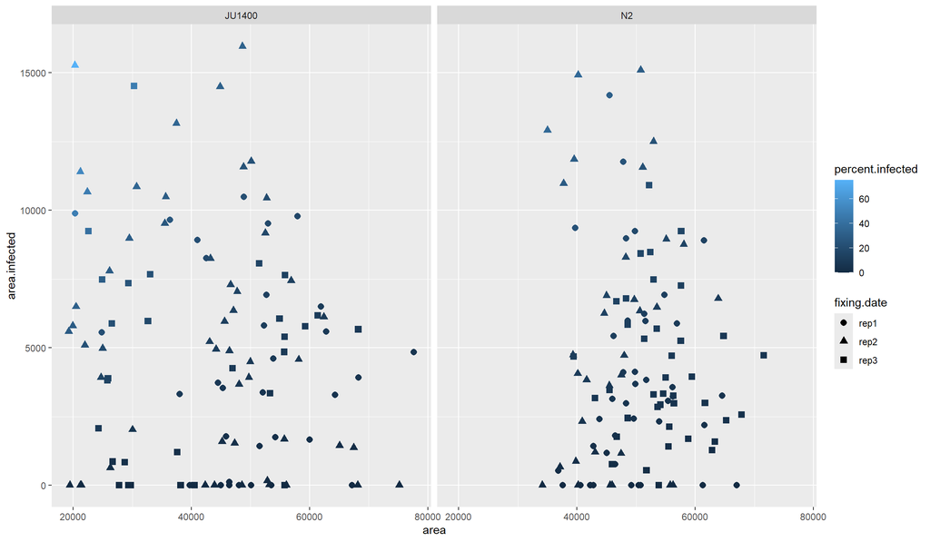

```r
# Change our point shape by fixing date and facet by Depth

# Add our data points to the ggplot object
infection_sig.df %>%
  # Filter the strains we'll investigate
  filter(strain %in% c("N2", "JU1400")) %>%

  # 1. Data
  ggplot(.) +
    # 2. Aesthetics
    aes(x = area, y = area.infected, colour = percent.infected, shape = fixing.date) +
    # 3. Scaling
    # 4. Geoms
    geom_point(size = 2.5) +
    # 6. Facets
    facet_grid(. ~ strain) # use facet_grid to split panels by worm strain
```

It looks like our shapes are pretty evenly distributed across the x-axis within each grouping, suggesting that (for the most part) our replicates are relatively consistent in overall animal size (area)! That’s perhaps a good sign that we aren’t likely to run into any replicate-based errors when doing statistical analyses of these populations but our y-axis distributions don’t appear as clear cut at the moment.

### 1.2.13 There are numerous ways to specify `facet_*()`

Note that up until now we’ve been using `facet_grid(~variable)` to split our data by variable. This annotation causes the grids to be distributed horizontally. Other ways to facet by a *single* variable are:

- `facet_grid(variable~.)` will distribute your grids vertically
- `facet_wrap(~variable)` will return a symmetrical matrix of plots based on levels in your variable.

We can now see that perhaps across both N2 and JU1400, the “rep2” dataset resulted in higher infected area values. This could be a function of specific temperature or doubling time of the spores, or perhaps the total amount of spores used to infect these samples. This is definitely a rep to keep a closer eye on as we may wish to replace this with a more consistent replicate.

One thing that is not necessary in this case - but good to know about - is the ability to allow each grid to have its own independent axis scale. For instance, if the range of our animals varied much more between strains, it might make more sense to allow for separate x and y-axis values between the two data sets. This can be changed, but keep in mind most people will assume all grids have the same scale, so take extra care to point out that the scales are different when presenting or publishing.

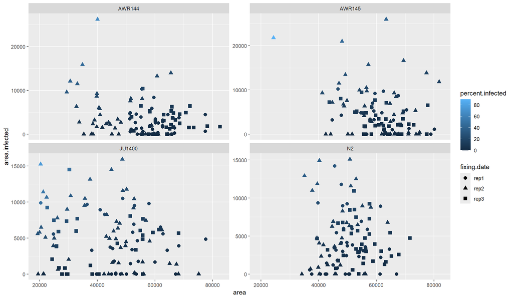

```r
# Use facet_wrap to rescale our y-axis individually

# Add our data points to the ggplot object
infection_sig.df %>%

  # 1. Data
  ggplot(.) +
    # 2. Aesthetics
    aes(x = area, y = area.infected, colour = percent.infected, shape = fixing.date) +
    # 3. Scaling
    # 4. Geoms
    geom_point(size = 2.5) +
    # 6. Facets
    facet_wrap(. ~ strain, scales = "free_y") # use facet_grid to split panels by worm strain
```

### 1.2.14 `facet_grid()` and `vars()` to subgroup by multiple variables from your data

To accomplish this, we turn to the `facet_grid()` function and two parameters:

- `cols`: the variable you wish to distribute across columns
- `rows`: the variable you wish to distribute across rows

To work with these parameters we’ll use the `vars()` helper function which will evaluate variables or expressions in the context of the accompanying dataset. We can provide `vars()` with one or more data variable names. In this way, `vars()` can be used to create subgroups in a manner similar to `group_by()`.

We’ll show two similar examples using `facet_wrap()` and `facet_grid()` layers. Note that `facet_grid()` gives clearer control over how the data is partitioned.

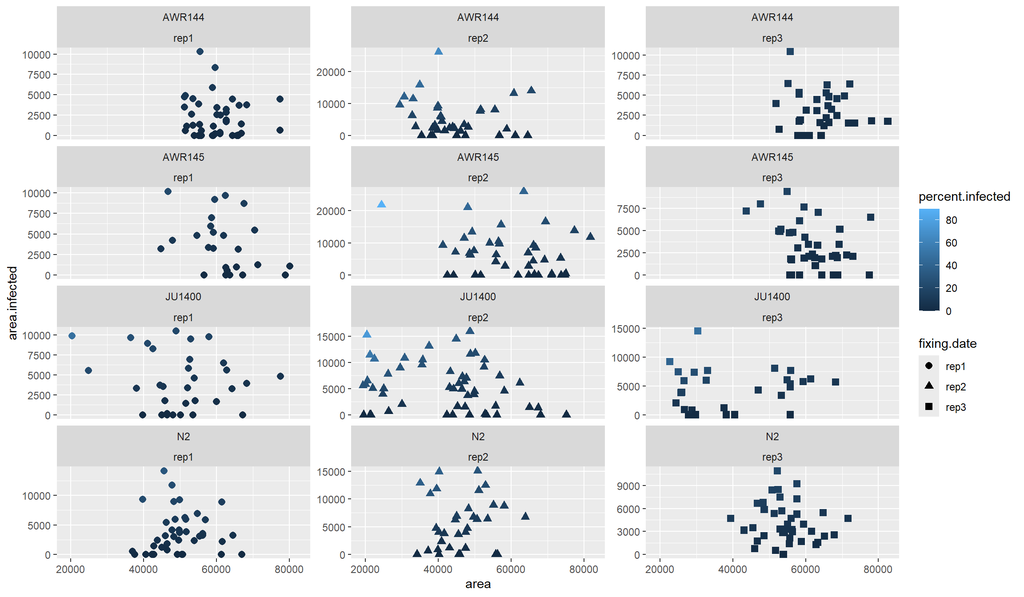

```r
# Use facet_wrap() and vars() to subgroup our data

# Add our data points to the ggplot object
infection_sig.df %>%

  # 1. Data
  ggplot(.) +
    # 2. Aesthetics
    aes(x = area, y = area.infected, colour = percent.infected, shape = fixing.date) +
    # 3. Scaling
    # 4. Geoms
    geom_point(size = 2.5) +
    # 6. Facets
    facet_wrap(facets = vars(strain, fixing.date), scales = "free_y",
               ncol = 3
              ) # use facet_grid to split panels by worm strain
```

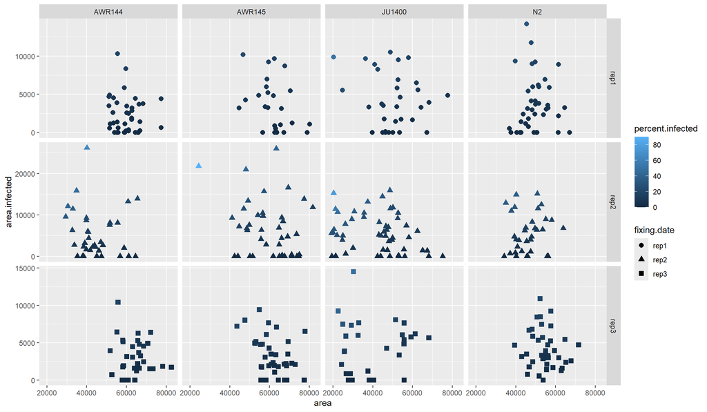

```r
# Use facet_grid() and vars() to subgroup our data

# Add our data points to the ggplot object
infection_sig.df %>%

  # 1. Data
  ggplot(.) +
    # 2. Aesthetics
    aes(x = area, y = area.infected, colour = percent.infected, shape = fixing.date) +
    # 3. Scaling
    # 4. Geoms
    geom_point(size = 2.5) +
    # 6. Facets
    facet_grid(cols = vars(strain),
               rows = vars(fixing.date),
               scales = "free_y") # use facet_grid to split panels by worm strain
```

So our initial observations were correct in deducing that `rep2` data appeared to have a higher range for area of infection versus `rep1` and `rep3` datasets. We can also see that JU1400 animals have a wider distribution of size ranges than the other 3 strains from our experiment.

Notice how `facet_grid()` produces a much cleaner set of titles and organization for its panels.

## 1.3.0 Add regression lines using statistical transformations

You can also add **statistical transformations** to your plots. Again, take a look at `stat_` then use `Tab` to see the list of options. In this case let’s separately fit a linear regression line to `area` vs `area.infected` for each facet. The grey area around the line is the confidence interval (default=0.95) and can be removed with the additional call to stat_smooth of `se = FALSE`.

In our first example, we’ll return the plot to show all data points as the same size.

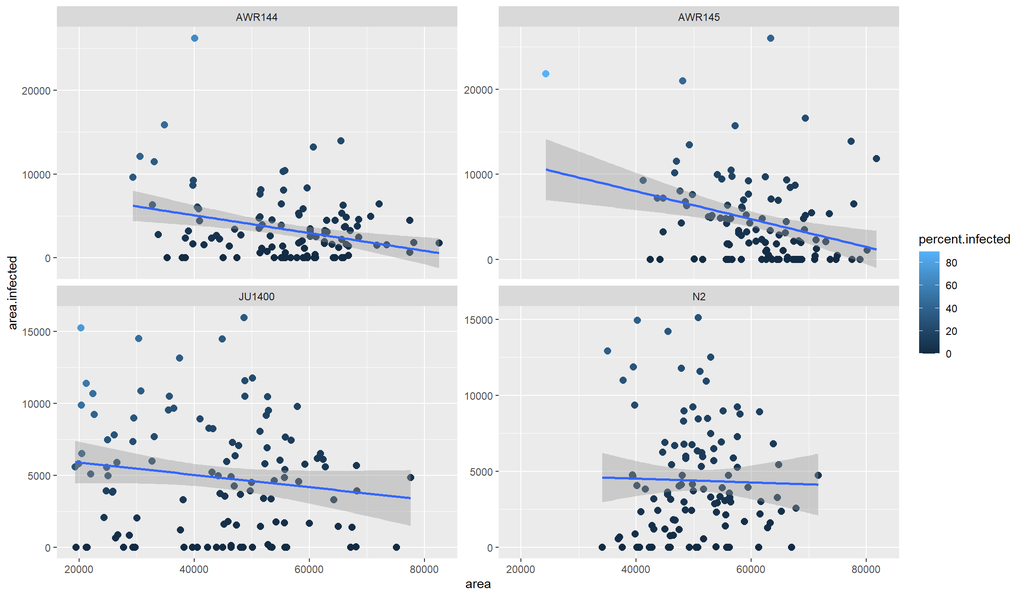

```r
# Add our regression line with stat_smooth

# Add our data points to the ggplot object
infection_sig.df %>%

  # 1. Data
  ggplot(.) +
    # 2. Aesthetics
    aes(x = area, y = area.infected, colour = percent.infected) +
    # 3. Scaling
    # 4. Geoms
    geom_point(size = 2.5) +
    # 5. statistics
    stat_smooth(method = lm) + ### 1.3.0 add in some regression lines for our data
    # 6. Facets
    facet_wrap(. ~ strain, scales = "free_y") # use facet_grid to split panels by worm strain
```

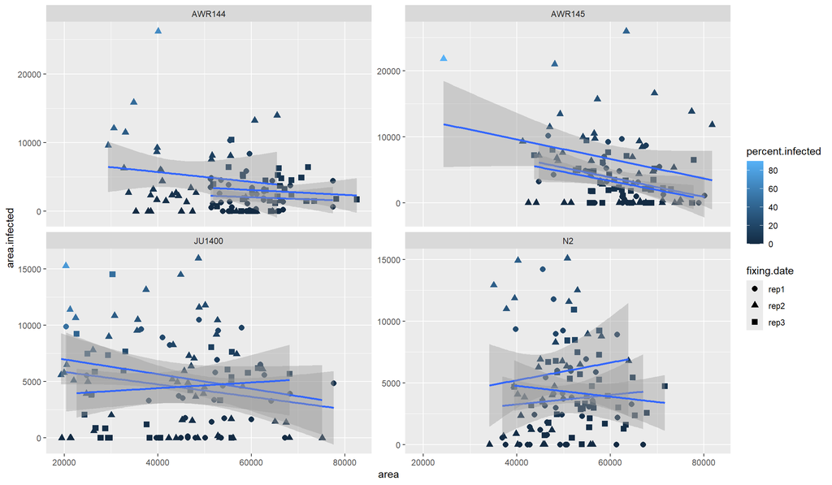

```r
# Add our regression line with stat_smooth but also group by fixing.date

# Add our data points to the ggplot object
infection_sig.df %>%

  # 1. Data
  ggplot(.) +
    # 2. Aesthetics
    # 1.3.0-2 use the shape attribute to distinguish reps
    aes(x = area, y = area.infected, colour = percent.infected, shape = fixing.date) +
    # 3. Scaling
    # 4. Geoms
    geom_point(size = 2.5) +
    # 5. statistics
    stat_smooth(method = lm) + ### 1.3.0 add in some regression lines for our data
    # 6. Facets
    facet_wrap(. ~ strain, scales = "free_y") # use facet_grid to split panels by worm strain
```

Notice in our second faceted plot that we have *multiple* regression lines per panel. This is because by setting the `aes(shape = fixing.date)` parameter, we have regrouped the data based on `fixing.date` of which there are 3 factor levels.

### 1.3.1 Play around with regression models and use the `alpha` parameter to *de-emphasize* data

A linear model is not always the best fit. The method of calculating the smoothing function can be changed to other provided functions (such as loess - short for local regression, used below) or can be a custom formula. We’ll talk more about making our own models in **Lecture 06**! Note that I changed the confidence interval by modifying `level=0.8`.

`geoms_*` can also be made more transparent with the `alpha` parameter, which is set to 0.3 in the following code so that the emphasis is on the regression line rather than the points.

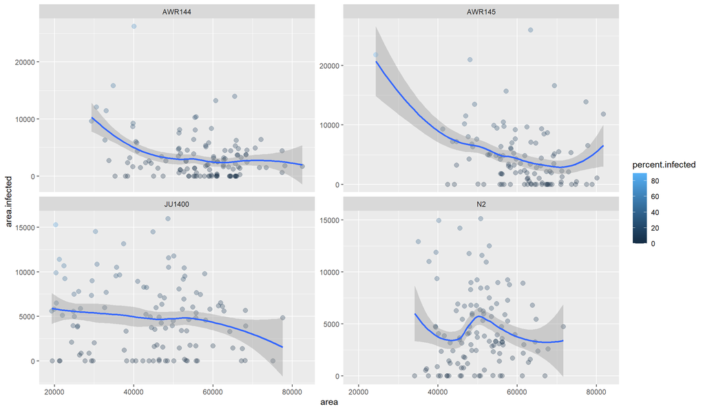

```r
# Set the alpha on geom_point and change our regression method

# Add our data points to the ggplot object
infection_sig.df %>%

  # 1. Data
  ggplot(.) +
    # 2. Aesthetics
    aes(x = area, y = area.infected, colour = percent.infected) +
    # 3. Scaling
    # 4. Geoms
    geom_point(size = 2.5, alpha = 0.3) +
    # 5. statistics
    stat_smooth(method = loess, level = 0.8) + ### 1.3.1 add in some regression lines for our data
    # 6. Facets
    facet_wrap(. ~ strain, scales = "free_y") # use facet_grid to split panels by worm strain
```

**Comprehension Question 1.0.0:** Now that we’ve built a few basic scatterplots, you may have noticed that our last plot faceted the strains in order of AWR144, AWR145, JU1400, and N2. In fact, we’d like to see a different order of N2 (our lab reference control), JU1400 (a wild isolate), AWR144, and AWR145 (derivatives of JU1400). How would you go about fixing the order? Use the coding cell provided to update the visualization.

```r
# comprehension answer code 1.0.0
# Change the order of how our faceted graph is displayed

# Add our data points to the ggplot object
infection_sig.df %>%
... %>%

  # 1. Data
  ggplot(.) +
    # 2. Aesthetics
    aes(x = area, y = area.infected, colour = percent.infected) +
    # 3. Scaling
    # 4. Geoms
    geom_point(size = 2.5, alpha = 0.3) +
    # 5. statistics
    stat_smooth(method = loess, level = 0.8) + ### 1.3.1 add in some regression lines for our data
    # 6. Facets
    facet_wrap(. ~ strain, scales = "free_y") # use facet_grid to split panels by worm strain
```

# 2.0.0 Exploring different types of distribution plots

Now that we have some of the basics, it’s time to take a closer look at using other types of plots. In this section we’ll focus on distribution plots which can help us visualize the spread or *distribution* of data in various ways such as with:

- Kernel Density Estimate (think smooth histograms)
- Histograms
- Barplots
- Boxplots

We’ll begin by reviewing the `embryo_data_long_merged.csv` dataset after loading it into memory as the variable `embryo_long.df`.

We’ll use the `col_types` parameter to let us define the variable types of the data as we import it.

```r
# Load the tidyverse package
# library(tidyverse)

embryo_long.df <- read_csv("data/embryo_data_long_merged.csv",
                           # Here we are explicitly specifying our column types
                           col_types = 'cnfffnnfllnnfnnffff')

# Take a look at the  metadata structure
str(embryo_long.df, give.attr = FALSE)
```

```
## spc_tbl_ [9,802 x 19] (S3: spec_tbl_df/tbl_df/tbl/data.frame)
##  $ experiment    : chr [1:9802] "200707_N2_LUAm1_0M_72hpi" "200707_N2_LUAm1_10M_72hpi" "200707_JU1400_LUAm1_0M_72hpi" "200707_JU1400_LUAm1_10M_72hpi" ...
##  $ worm.number   : num [1:9802] 1 1 1 1 1 1 1 1 1 1 ...
##  $ Infection Date: Factor w/ 9 levels "200704","200711",..: 1 1 1 1 1 1 1 1 1 1 ...
##  $ wormStrain    : Factor w/ 18 levels "N2","JU1400",..: 1 1 2 2 3 3 4 4 5 5 ...
##  $ sporeStrain   : Factor w/ 6 levels "LUAm1","MAM1",..: 1 1 1 1 1 1 1 1 1 1 ...
##  $ sporeDose     : num [1:9802] 0 10 0 10 0 10 0 10 0 10 ...
##  $ Spores(M)/cm2 : num [1:9802] 0 0.354 0 0.354 0 ...
##  $ doseLevel     : Factor w/ 6 levels "Mock","Medium",..: 1 2 1 2 1 2 1 2 1 2 ...
##  $ spores        : logi [1:9802] FALSE FALSE FALSE FALSE FALSE FALSE ...
##  $ meronts       : logi [1:9802] FALSE TRUE FALSE TRUE FALSE TRUE ...
##  $ embryos       : num [1:9802] 18 7 10 0 12 0 5 9 11 0 ...
##  $ expTimepoint  : num [1:9802] 72 72 72 72 72 72 72 72 72 72 ...
##  $ infection.type: Factor w/ 1 level "continuous": 1 1 1 1 1 1 1 1 1 1 ...
##  $ Total Worms   : num [1:9802] 1000 1000 1000 1000 1000 1000 1000 1000 1000 1000 ...
##  $ Plate Size    : num [1:9802] 6 6 6 6 6 6 6 6 6 6 ...
##  $ fixingDate    : Factor w/ 9 levels "200707","200714",..: 1 1 1 1 1 1 1 1 1 1 ...
##  $ Staining Date : Factor w/ 10 levels "200803","200810",..: 1 1 1 1 1 1 1 1 1 1 ...
##  $ Slide date    : Factor w/ 9 levels "200804","200811",..: 1 1 1 1 1 1 1 1 1 1 ...
##  $ Imaging Date  : Factor w/ 13 levels "200806","200813",..: 1 1 1 1 1 1 1 1 1 1 ...
```

**Specifying column types with read_csv():** In lecture 02 we allowed read_csv() to directly import our files and make an educated guess on what kind of data was held within. Above we have used the **col_types** argument and set it using a string of characters that denote shorthand representation for the data type each column. We can use **c** (character), **i** (integer), **d** (double), **l** (logical), **f** (factor), and [much more!](https://readr.tidyverse.org/reference/read_delim.html) Just be sure you know the column types for all columns in your input! Importing our data this way saves us an extra set of **mutate()** calls later down the road.

### 2.0.1 Apply complex functions to grouped data with `group_modify()`

A quick side note before we continue! Last lecture we spent some time playing with the `group_by()` and `summarize()` functions to help generate quick data summaries. There are, however, limitations to `summarize()` and sometimes you might wish to perform more complex analyses.

The `group_modify()` function allows you to *apply* a function to each group. This should sound very familiar to the idea behind the `apply()` family of functions. In the case of `group_modify()`, the parameters we are concerned with are:

- `.data`: the grouped tibble that we are providing for analysis.
- `.f`: a function that we wish to apply to the group.
- `...`: additional arguments passed on to `.f`.

**Shortcut functions with the purr package:** Note that in the following code we’ll use the **“~”** in a special way as a shortcut syntax to denote that we are making a new function. This is similar to how functions are defined in the **apply()** family of functions except it allows us to assign the incoming input to the variable **“.x”** which we can then manipulate as needed. We’ll learn more about making our own functions in **Lecture 07**.

For our newly-imported dataset, we are interested in retrieving the mean embryo number for each worm strain replicate (ie `Infection Date`) under the uninfected (ie Mock) treatment condition.

```r
embryo_long.df %>%
  # Group by experiment
  group_by(experiment) %>%
  # Just grab mock infection experiments
  filter(doseLevel == "Mock") %>%
  # Grab the mean embryo count for each exp and make that a new column
  mutate(meanEmb = mean(embryos)) %>%
  # Grab the first entry of each group
  group_modify(.data = ., .f = ~ head(.x, 1L)) %>%
  # Take a peek at the resulting tables
  head(10)
```

```
## # A tibble: 10 x 20
## # Groups:   experiment [10]
##    experiment      worm.number `Infection Date` wormStrain sporeStrain sporeDose
##    <chr>                 <dbl> <fct>            <fct>      <fct>           <dbl>
##  1 190426_AB1_LUA~           1 190423           AB1        LUAm1               0
##  2 190426_CB4856_~           1 190423           CB4856     ERTm5               0
##  3 190426_ED3042_~           1 190423           ED3042     LUAm1               0
##  4 190426_JU1400_~           1 190423           JU1400     ERTm5               0
##  5 190426_JU1400_~           1 190423           JU1400     LUAm1               0
##  6 190426_JU300_E~           1 190423           JU300      ERTm5               0
##  7 190426_JU360_E~           1 190423           JU360      ERTm2               0
##  8 190426_JU360_L~           1 190423           JU360      LUAm1               0
##  9 190426_JU397_L~           1 190423           JU397      LUAm1               0
## 10 190426_JU642_L~           1 190423           JU642      LUAm1               0
## # i 14 more variables: `Spores(M)/cm2` <dbl>, doseLevel <fct>, spores <lgl>,
## #   meronts <lgl>, embryos <dbl>, expTimepoint <dbl>, infection.type <fct>,
## #   `Total Worms` <dbl>, `Plate Size` <dbl>, fixingDate <fct>,
## #   `Staining Date` <fct>, `Slide date` <fct>, `Imaging Date` <fct>,
## #   meanEmb <dbl>
```

Each row in our above output now holds an additional variable, `meanEmb`, which represent the mean number of embryos present in each *experimental* grouping. If we were to look at the whole grouped_df object, we would see the same `meanEmb` value in each row sharing the same `experiment` grouping. In our final output we used our `group_modify()` step to retrieve just a *single row* from each experimental subgroup.

### 2.0.2 Populate values across groups with `*_join()`

In the world of *C. elegans* embryo experiments, there are many factors that can influence reproductive outcomes. While we can reduce intra-experimental variation by using the same source of animals, we may experience inter-experimental variation that can change how well populations of nematodes reproduce.

In order to compare our replicate experiments in a meaningful way, we can *normalize* our data against these baseline values. You might find the need for similar methods when analysing fluorescent microscopy images.

With our Mock-infection (untreated) condition in a tidy little table, we can now normalize our original datasets with the uninfected baseline for each strain in each specific replicate. All it takes is a little `select()` and `*_join()` power!

Using the `inner_join()` we can pass along our `meanEmb` variable as a new variable for each observation and the value will be based on matching the `Infection Date`, `wormStrain`, and `expTimepoint` variables. We’ll let `inner_join()` automatically identify these overlapping variables during the merging process.

We’ll save our normalized data into `embryo_norm.df`.

```r
embryo_norm.df <-
  embryo_long.df %>%
  # Group by a few specific variables
  group_by(`Infection Date`, wormStrain, expTimepoint) %>%
  # Just grab mock infection experiments
  filter(doseLevel == "Mock") %>%
  # Grab the mean embryo count for each exp and make that a new column
  mutate(meanEmb = mean(embryos)) %>%
  # Grab the first entry of each group
  group_modify(~ head(.x, 1L)) %>%

  ### Now we have equivalently a summary table of the group means    ###
  ### BUT we also have experimental conditions that they represent!  ###

  # Ungroup the data and treat like a normal table
  ungroup() %>%
  # We only need to select a few columns from our data - enough to properly join to the original data.
  select(`Infection Date`, wormStrain, expTimepoint, meanEmb) %>%

  # Join the data with the original with the normalization information
  inner_join(x = embryo_long.df, y = .) %>%

  # Create a normalized embryo variable by calculating embryos/meanEmb for each observation!
  mutate(normEmb = embryos/meanEmb) %>%

  # Sort data based on experiment name
  arrange(experiment)
```

[output not shown]

```r
# Take a look at the resulting dataframe
head(embryo_norm.df)
```

```
## # A tibble: 6 x 21
##   experiment       worm.number `Infection Date` wormStrain sporeStrain sporeDose
##   <chr>                  <dbl> <fct>            <fct>      <fct>           <dbl>
## 1 190426_AB1_LUAm~           1 190423           AB1        LUAm1               0
## 2 190426_AB1_LUAm~           2 190423           AB1        LUAm1               0
## 3 190426_AB1_LUAm~           3 190423           AB1        LUAm1               0
## 4 190426_AB1_LUAm~           4 190423           AB1        LUAm1               0
## 5 190426_AB1_LUAm~           5 190423           AB1        LUAm1               0
## 6 190426_AB1_LUAm~           6 190423           AB1        LUAm1               0
## # i 15 more variables: `Spores(M)/cm2` <dbl>, doseLevel <fct>, spores <lgl>,
## #   meronts <lgl>, embryos <dbl>, expTimepoint <dbl>, infection.type <fct>,
## #   `Total Worms` <dbl>, `Plate Size` <dbl>, fixingDate <fct>,
## #   `Staining Date` <fct>, `Slide date` <fct>, `Imaging Date` <fct>,
## #   meanEmb <dbl>, normEmb <dbl>
```

However, if you look closely at the code, we could have simply skipped the `inner_join()` step by working with our original grouped and mutated dataset. Since we had already broadcast each group’s meanEmb value to a new column, we could simply continue from there to calculate the normalized embryo values.

```r
  embryo_long.df %>%
  # Group by a few specific variables
  group_by(`Infection Date`, wormStrain, expTimepoint) %>%
  # Just grab mock infection experiments
  filter(doseLevel == "Mock") %>%
  # Grab the mean embryo count for each exp and make that a new column
  mutate(meanEmb = mean(embryos)) %>%

  # Ungroup the data and treat like a normal table. This is crucial to broadcast in an element-wise manner
  ungroup() %>%

  # Create a normalized embryo variable by calculating embryos/meanEmb for each observation!
  mutate(normEmb = embryos/meanEmb) %>%
  arrange(experiment) %>%
  head()
```

```
## # A tibble: 6 x 21
##   experiment       worm.number `Infection Date` wormStrain sporeStrain sporeDose
##   <chr>                  <dbl> <fct>            <fct>      <fct>           <dbl>
## 1 190426_AB1_LUAm~           1 190423           AB1        LUAm1               0
## 2 190426_AB1_LUAm~           2 190423           AB1        LUAm1               0
## 3 190426_AB1_LUAm~           3 190423           AB1        LUAm1               0
## 4 190426_AB1_LUAm~           4 190423           AB1        LUAm1               0
## 5 190426_AB1_LUAm~           5 190423           AB1        LUAm1               0
## 6 190426_AB1_LUAm~           6 190423           AB1        LUAm1               0
## # i 15 more variables: `Spores(M)/cm2` <dbl>, doseLevel <fct>, spores <lgl>,
## #   meronts <lgl>, embryos <dbl>, expTimepoint <dbl>, infection.type <fct>,
## #   `Total Worms` <dbl>, `Plate Size` <dbl>, fixingDate <fct>,
## #   `Staining Date` <fct>, `Slide date` <fct>, `Imaging Date` <fct>,
## #   meanEmb <dbl>, normEmb <dbl>
```

## 2.1.0 View the theoretical distribution of your data with KDE plots

Now that we have our data normalized, we can better compare or combine our replicates for analysis. There are so many observations for each replicate in our data, that it would be nice to see the overall spread of our data. This can be accomplished by simply plotting the data points but with a dense dataset, you might see too much overlap or run into issue with more discrete values. Instead, you might want to know the theoretical distribution of your data - ie the frequency of datapoints you are working with. This kind of plot is known as a kernel density estimate (KDE).

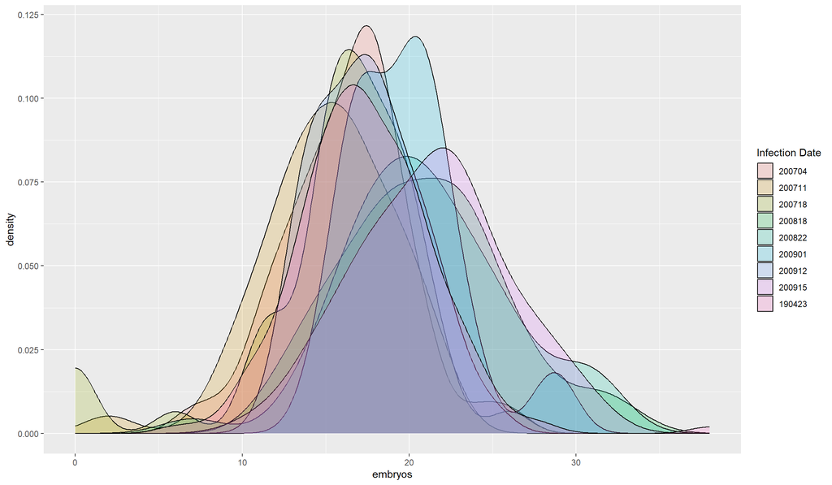

```r
# Build a density plot of your data

embryo_norm.df %>%
  # Filter for uninfected N2 observations
  filter(wormStrain == "N2", doseLevel == "Mock") %>%

  # 1. Data
  ggplot(.) +
    # 2. Aesthetics
    aes(x = embryos, fill = `Infection Date`) +
    # 4. Geoms
    geom_density(alpha = 0.2)
```

As we can see from above, even using a lab reference strain, there can be quite a bit of variation in the distribution of embryo production with our distribution peaks ranging from 15-22. It’s a good thing we normalized the data. Let’s take a quick look at that version for comparison.

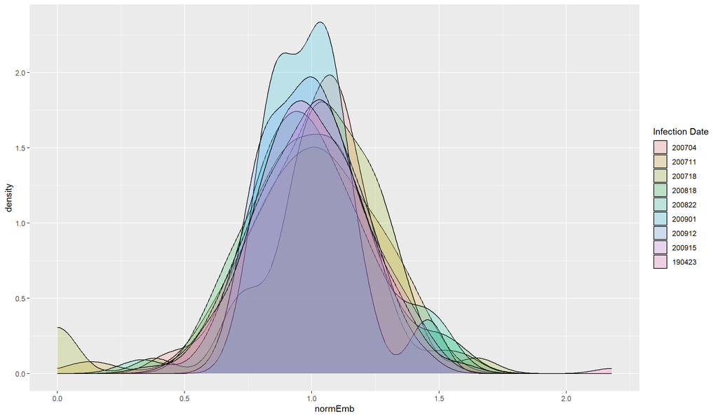

```r
# Build a density plot of your data

embryo_norm.df %>%
    # Filter for uninfected N2 observations
    filter(wormStrain == "N2", doseLevel == "Mock") %>%

    # 1. Data
    ggplot(.) +
        # 2. Aesthetics
        aes(x=normEmb, fill=`Infection Date`) +
        # 4. Geoms
        geom_density(alpha=0.2)
```

You can see that the normalized values center closer around 1.0! So despite the absolute mean values that might occur between experiments, the overall distribution of embryos is mostly consistent to within 0.5-1.5x of the population mean. This suggests that there are likely some environmental variables that are slightly affecting the overall number of embryos between replicates.

### 2.1.1 Set the limits of your axes with `*lim()`

From both versions of our distributions, we can see that one of the replicates dates (200718) produced a portion of N2 animals with 0 embryos suggesting there may have been some problems with the preparation of these animals. In some cases, you might wish to change your x or y-limits on your axes. This can sometimes be helpful if you have a very long left or right tail, or a partially bimodal distribution where you want to focus in on a single distribution.

You can quickly alter the x and y-axis limits with the `xlim()` and `ylim()` layers respectively. You simply need to provide 2 parameters - a lower and upper range.

Let’s do the following:

1. Set upper and lower x-axis boundaries with `xlim()`.
2. Add a `geom_rug()` layer so that we can see where each value falls along the distribution.

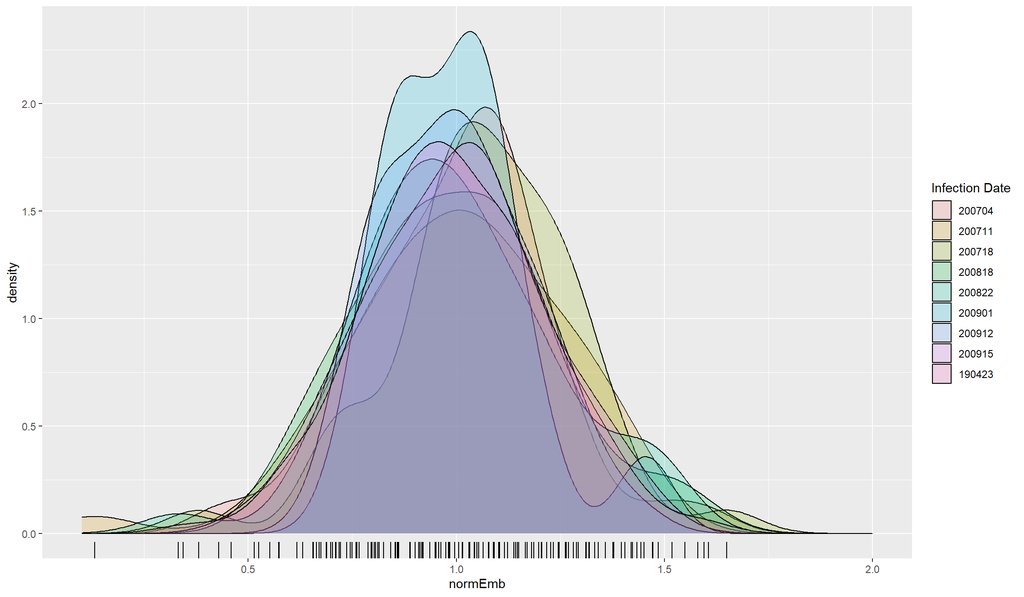

```r
# Change our x-axis limits and add a geom_rug()
embryo_norm.df %>%
  # Filter for uninfected N2 observations
  filter(wormStrain == "N2", doseLevel == "Mock") %>%

  # 1. Data
  ggplot(.) +
    # 2. Aesthetics
    aes(x=normEmb, fill=`Infection Date`) +
    # 3. Scaling
    xlim(0.1,2) +             ### 2.1.1 add x-axis limits
    # 4. Geoms
    geom_density(alpha=0.2) +
    geom_rug()
```

```r
  # geom_rug adds lines on the desired axis to indicate data points.
  # Rug plots display individual cases so are best used with smaller datasets.
```

## 2.2.0 Histograms can similarly visualize our distribution

Unlike density plots, histograms count the number of observations you have in each ‘bin’ that you specify. So with proper parameters you can recreate a similar shape to your density plots using only the observed data.

**Of bins and binwidths:** The `geom_histogram()` function uses a default `bin` value of 30 units, which means your data will be *subdivided* into 30 bins along your x-axis. The geom itself is agnostic to your data, its values, or the meaning (units) of those values. This is simply a *default behaviour* and you should change it yourself. **R** will even warn you to change your binwidth using the either the `bins` or `binwidth` parameters. The former will set the number of bins, the latter the actual width of the bins.

```
## Warning: Removed 4 rows containing non-finite outside the scale range
## (`stat_bin()`).
```

```
## Warning: Removed 18 rows containing missing values or values outside the
## scale range (`geom_bar()`).
```

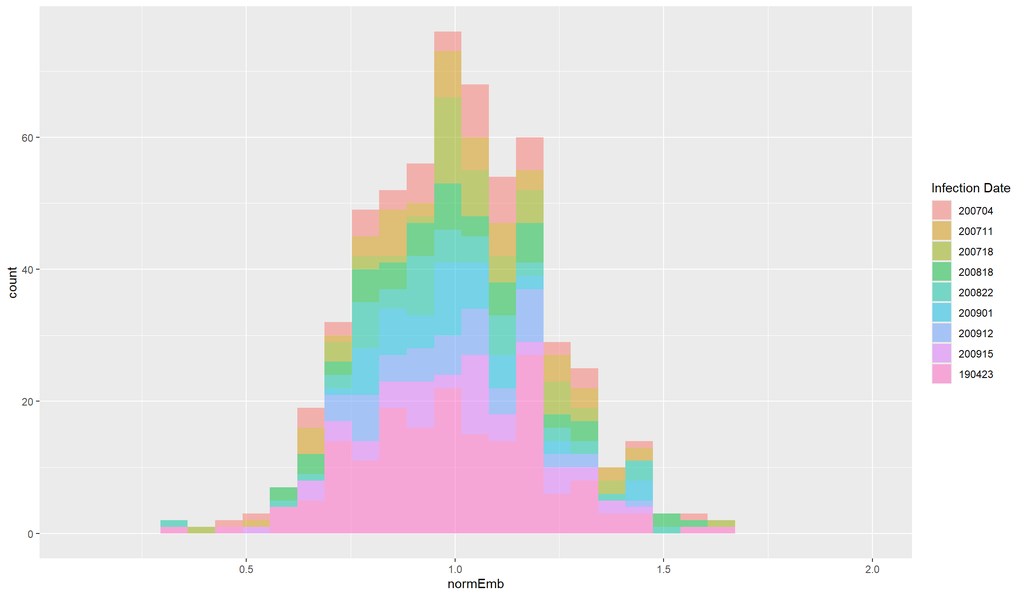

```r
embryo_norm.df %>%
  # Filter for uninfected N2 observations
  filter(wormStrain == "N2", doseLevel == "Mock") %>%

  # 1. Data
  ggplot(.) +
    # 2. Aesthetics
    aes(x=normEmb, fill=`Infection Date`) +
    # 3. Scaling
    xlim(0.1, 2) +
    # 4. Geoms
    geom_histogram(alpha = 0.5)   ### 2.2.0 change it up to a histogram geom
```

### 2.2.1 Use the `position` parameter to alter how data is stacked

Instead of having the `normEmb` information stacked, we may want to see the data side by side. This can be done with the parameter `position` set to `dodge`. It’s not extremely helpful to dodge your data this way when you have many groups, but if you have just a 2 or 3, then the dodge will not look too strange. Let’s try the following:

1. Filter the data to focus on just 3 replicates
2. Alter the bin width of the histogram.
3. Dodge our data
4. Add a y-axis limit with `ylim()`
5. Add a `geom_rug()`

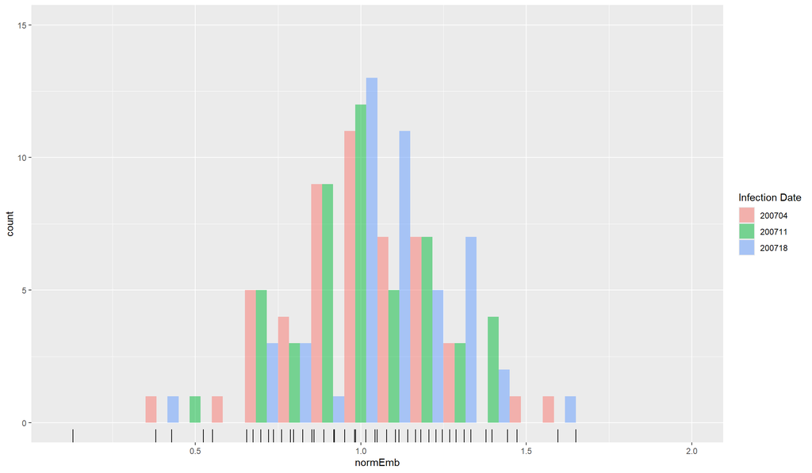

```r
# Update with dodging the data, ylim and geom_rug

embryo_norm.df %>%
  # Filter for uninfected N2 observations
  filter(wormStrain == "N2", doseLevel == "Mock", `Infection Date` %in% c("200704", "200711", "200718")) %>%

  # 1. Data
  ggplot(.) +
    # 2. Aesthetics
    aes(x=normEmb, fill=`Infection Date`) +

    # 3. Scaling
    xlim(0.1, 2) +
    ylim(0, 15) +

    # 4. Geoms
    ### 2.2.1 change up the histogram parameters
    geom_histogram(binwidth = 0.1, position = "dodge", alpha = 0.5) +
    geom_rug()
```

So for a small number of groups, we can use this kind of approach to look at our data if a histogram is your desired visualization. Of the 3 options, however, a KDE certainly seems the clearest right? Be wary, however, of small population sample sizes since larger variations in these can bias your results. There are also a number of [additional `geom_density()` parameters](https://ggplot2.tidyverse.org/reference/geom_density.html) that can affect your final visualization.